# Spatio-temporal downscaling of temperature and VPD data

Pepa Arán

2023-08-31

This report presents an Applied Geo-Data Science project aimed at spatially downscaling daily Vapor Pressure Deficit (VPD) and temperature values to address vegetation modelling questions. By improving the spatial resolution of climatic data, we can gain valuable insights into the relationships between environmental variables and vegetation dynamics at finer scales. Recent literature (Peñuelas et al. 2017; Wang et al. 2020) indicates a change of paradigm, where warming dominates photosynthesis, rather than CO$_2$ fertilization. The global rise in temperature, thus also increased VPD, is leading to reduced vegetation growth (Yuan et al. 2019). Understanding this pressing issue with high resolution data is a motivator for the project here presented.

This project proposes the integration of daily meteorological data from the WATCH-WFDEI dataset (Weedon et al. 2014) with a finer spatial grid dataset like Worldclim (Fick and Hijmans 2017), which provides averaged values over 30 years, to achieve higher spatial resolution. Average daily temperature data is directly provided in both datasets and we will use measurements of specific humidity from WATCH-WFDEI and vapour pressure from Worldclim to compute VPD. A simple de-biasing technique will be employed to combine the two datasets effectively. Finally, the quality of the downscaling will be evaluated through various means, including visualization and comparison with temperature and VPD measurements from FLUXNET2015 (Pastorello et al. 2020) sites.

## Data selection

The following datasets were chosen among a variety of public datasets, because, combined, they allow us to obtain daily values of temperature and vapor pressure deficit at a very fine spatial resolution (30 seconds or cells of approximately 700m (lon) by 900m (lat) in Switzerland).

### Daily global climate data from WATCH-WFDEI

- **Tair** is the daily average (of 3-hourly) near surface air temperature (in Kelvin) at 2m at time stamp
- **Qair** is the daily average specific humidity (in kg/kg) at 2m above surface
- **PSurf** is the daily average surface pressure (in hPa)

The data can be downloaded from the IIASA website via ftp for each variable separately. We used the `src/download_watch_wfdei.sh` script to get the data automatically.

After downloading the data, we can read the netCDF files with the `terra` package and extract the information we are interested in. For example, `Tair_daily_WFDEI_197901.nc` contains average temperature values for each day of January 1979 and each pixel in a 0.5 degree grid (approximately 55x55km cells at the equator and 55x42km at the latitude of Switzerland) covering the whole globe.

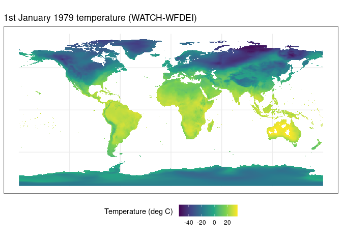

```r
# Path for WATCH-WFDEI data (directory containing the .nc files)
path_watch <- "data-raw/wfdei_weedon_2014"

# Read the temperature data for January, K -> deg C
temp_watch <- terra::rast(paste0(path_watch,
                                "/Tair_daily/Tair_daily_WFDEI_197901.nc")) - 273.15

# Plot month averages
ggplot() +
  tidyterra::geom_spatraster(data = temp_watch |>
                               terra::subset(1)) +
  scale_fill_viridis_c(
    na.value = NA,
    name = "Temperature (deg C) \n",
    limits = c(-55, 35)
    ) +
  theme_bw() +
  theme(
    legend.position = "bottom") +
  labs(
    title = "1st January 1979 temperature (WATCH-WFDEI)"
    )
```

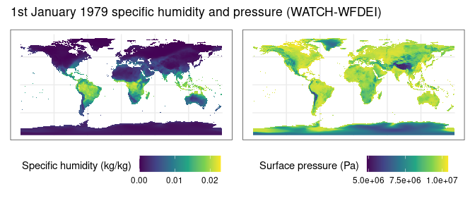

```r
# Read the specific humidity data
qair_watch <- terra::rast(paste0(path_watch,
                                "/Qair_daily/Qair_daily_WFDEI_197901.nc"))
# Read the surface pressure, hPa -> Pa
patm_watch <- terra::rast(paste0(path_watch,
                                 "/PSurf_daily/PSurf_daily_WFDEI_197901.nc")) * 100

# Plot variables informing VPD
p_qair <- ggplot() +
  tidyterra::geom_spatraster(data = qair_watch |>
                               terra::subset(1)) +
  scale_fill_viridis_c(
    na.value = NA,
    name = "Specific humidity (kg/kg) \n",
    limits = c(0, 0.023),
    breaks = c(0, 0.01, 0.02)
    ) +
  theme_bw() +
  theme(
    legend.position = "bottom")

p_patm <- ggplot() +
  tidyterra::geom_spatraster(data = patm_watch |>
                               terra::subset(1)) +
  scale_fill_viridis_c(
    na.value = NA,
    name = "Surface pressure (Pa) \n",
    limits = c(4.9e6, 1.04e7),
    breaks = c(5e6, 7.5e6, 1e7)
    ) +
  theme_bw() +
  theme(
    legend.position = "bottom")

patchw <- p_qair + p_patm
patchw + plot_annotation(
  title = "1st January 1979 specific humidity and pressure (WATCH-WFDEI)"
)
```

```r
# Path for WATCH-WFDEI data (directory containing the .nc files)
path_watch <- "data-raw/wfdei_weedon_2014/Qair_daily"

# Get the list of .nc files in the directory
file_list <- list.files(path_watch, pattern = "*.nc", full.names = TRUE)

# Read the temperature data for January, K -> deg C
temp_watch <- terra::rast(file_list[1]) - 273.15

# Plot month average
p_temp <- ggplot() +
  tidyterra::geom_spatraster(data = temp_watch |>
                               terra::app(mean, na.rm = TRUE)) +
  scale_fill_viridis_c(
    na.value = NA,
    name = "Temperature (deg C) \n",
    limits = c(-55, 35)
    ) +
  theme_bw() +
  theme(
    legend.position = "bottom") +
  labs(
    title = "Average January 1979 temperature (WATCH-WFDEI)"
    )
```

### Monthly climatology global maps from WorldClim

The WorldClim dataset contains historical climate data for the period 1970-2000, available at various spatial resolutions. The finest, 30” gridded data from WorldClim can be directly downloaded from https://www.worldclim.org/data/worldclim21.html as .zip files. We are interested in the following variables:

- **tavg**: average monthly temperature ($^\text{o}$C)
- **vapr**: water vapor pressure (kPa)

Below we show the average temperature and water vapor pressure across the globe in January, between the years 1970-2000.

```
## SpatRaster resampled to ncells = 5e+05
```

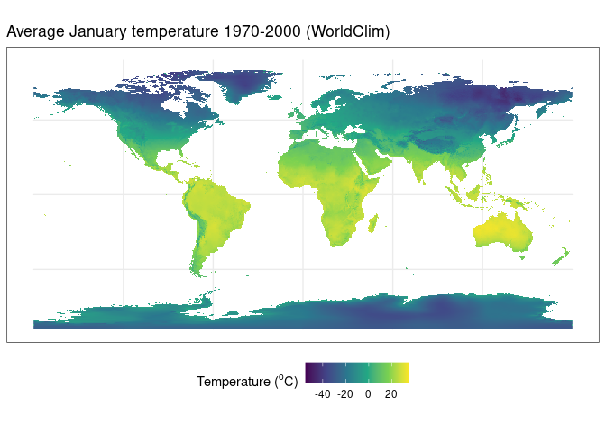

```r
# Path for WorldClim data
path_worldclim <- "data-raw/worldclim_fick_2017"

# Read the temperature data for January
temp_worldclim <- terra::rast(paste0(path_worldclim, "/wc2.1_30s_tavg_01.tif"))

# Plot average
ggplot() +
  tidyterra::geom_spatraster(data = temp_worldclim) +
  scale_fill_viridis_c(
    na.value = NA,
    name = expression(paste("Temperature ("^o, "C)")),
    limits = c(-55, 35)
    ) +
  theme_bw() +
  theme(
    legend.position = "bottom"
    ) +
  labs(
    title = "Average January temperature 1970-2000 (WorldClim)"
    )
```

```r
# Read the vapor pressure data for January
vapr_worldclim <- terra::rast(paste0(path_worldclim,
                                     "/wc2.1_30s_vapr_01.tif")) * 1000
```

```
##
|---------|---------|---------|---------|
=========================================
```

```
## SpatRaster resampled to ncells = 5e+05
```

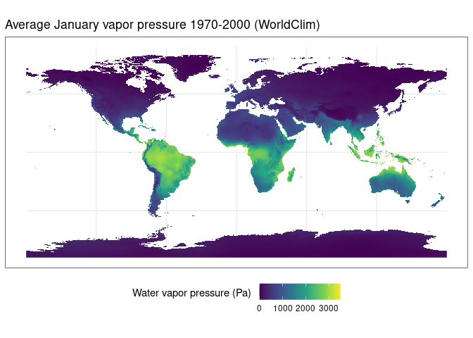

```r
# Plot average
ggplot() +
  tidyterra::geom_spatraster(data = vapr_worldclim) +
  scale_fill_viridis_c(
    na.value = NA,
    name = "Water vapor pressure (Pa) \n",
    limits = c(0, 3.5e3)
    ) +
  theme_bw() +
  theme(
    legend.position = "bottom"
    ) +
  labs(
    title = "Average January vapor pressure 1970-2000 (WorldClim)"
    )
```

These data are more granular than the maps from WATCH-WFDEI, which is particularly visible in mountainous regions. We even get a message indicating that the data had to be regridded to a lower resolution to be plotted.

Due to the fine spatial resolution of the WorldClim dataset, performing calculations on the monthly raster files is very memory intensive. Running the code locally is not feasible, therefore we focus on the area of Switzerland for the remainder of the project. Whenever bigger computational resources are available, the same code can be used to obtain global maps of downscaled values of temperature and VPD.

### Daily measurements from FLUXNET2015

The FLUXNET2015 dataset includes continuous measurements of ecosystem fluxes (CO2, water vapor, latent heat…) and physical variables (air temperature, precipitation, radiation…), from 212 sites around the world and in high temporal resolution (half-hourly, daily, monthly…). We will use these data as validation, because we want the downscaled data to approximate local measurements as closely as possible.

To download the data, it is necessary to create an AMERIFLUX account. After logging in, the data can be directly downloaded in .zip files from https://fluxnet.org/data/download-data/, filtering for the 6 Swiss sites with the prefix CH. All variables are described in the table [here](https://fluxnet.org/data/fluxnet2015-dataset/fullset-data-product/) and in the [AGDS I book](https://geco-bern.github.io/agds/datawrangling.html#example-data).

We are interested in the following variables from the daily files (DD):

- **TIMESTAMP**: Time stamp in short format (YYYYMMDDHHMM).
- **TA_F**: Air temperature (in $^\text{o}$C), averaged from half-hourly data into daily data and gap-filled.
- **TA_F_QC**: Quality flag for TA_F, indicating the fraction between 0-1 of measured temperature vs gap-filled data. 1 corresponds to measured data only.
- **VPD_F**: Vapor Pressure Deficit (in hPa), averaged from harlf-hourly data into daily data and gap-filled.
- **VPD_F_QC**: Quality flag for VPD_F, indicating the fraction between 0-1 of measured VPD vs gap-filled data. 1 corresponds to measured data only.

The time stamp allows to compare the measurements in this time-series to daily values from the downscaled raster files. Furthermore, we can filter the temperature and VPD time-series to retain only measured data, thus avoiding the comparison of our downscaled WATCH-WFDEI data with downscaled ERA5 data (which the FLUXNET product uses for gap filling).

Here we show the time series of temperature in the Davos site, together with the quality of the data (observed vs. gap-filled). Most of the data from 1997 to 2014 were measured, except for a period in 2005 and some sporadic days. For all the Swiss FLUXNET sites, more than 50% of the time-series comes from observations only.

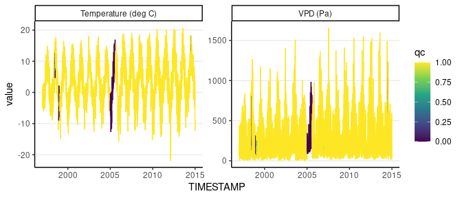

```r
# Define data path
path_fluxnet <- "data-raw/fluxnet_pastorello_2020"

# Read .csv file and select relevant variables
dd <- read.csv(paste0(path_fluxnet,
                      "/FLX_CH-Dav_FLUXNET2015_FULLSET_DD_1997-2014_1-4.csv")) |>
  dplyr::select(TIMESTAMP,
                TA_F,
                TA_F_QC,
                VPD_F,
                VPD_F_QC) |>
  dplyr::mutate(TIMESTAMP = as.Date(strptime(TIMESTAMP, format = "%Y%m%d")),
                VPD_F = VPD_F * 100)    # hPa -> Pa

# Prepare data for plotting
dd_plot <- data.frame(TIMESTAMP = dd$TIMESTAMP,
                      variable = c(rep("Temperature (deg C)", nrow(dd)),
                                   rep("VPD (Pa)", nrow(dd))),
                      value = c(dd$TA_F,
                                dd$VPD_F),
                      qc = c(dd$TA_F_QC,
                             dd$VPD_F_QC))

# Plot temperature and VPD in Davos
ggplot(data = dd_plot) +
  geom_line(aes(x = TIMESTAMP , y = value, col = qc)) +
  scale_color_viridis_c() +
  facet_wrap(~ variable, scales = 'free') +
  theme_classic() +
  theme(panel.grid.major.y = element_line())
```

## Data processing

The `terra` package simplifies the processing of all raster files. We implemented custom processing functions that read .tif (from WorldClim) and .nc (from WATCH-WFDEI) files, aggregate data over the time axis, re-grid raster files and perform complex operations to all data pixels. All these functions are stored in the `R/` folder.

### Calculating vapor pressure deficit (VPD)

Vapor Pressure Deficit is defined as the difference between the saturation vapor pressure ($e_s$) and the actual vapor pressure ($e$). It indicates the evaporative potential of air, therefore informing the rate of photosynthesis in vegetation models.

$$VPD = e_S - e$$
The saturation vapor pressure, i.e. the maximum amount of water vapor that air can hold, increases exponentially with warmer temperature. Warm air ca hold considerably more water when saturated than can colder air. It can be computed following eq. 5.1 in Evaporation and Evapotranspiration (Abtew and Melesse 2013),

$$e_S (T) = 611 \; \exp
\left({\frac{17.27 \; T}{T + 237.3}} \right)$$

where temperature ($T$) is given in degrees Celsius and the resulting $e_S$ is in Pa.

#### Computing VPD from WorldClim data

The [WorldClim dataset](https://www.worldclim.org/data/worldclim21.html) provides, among others, the following variables:

- **tavg**: average monthly temperature (Celsius)
- **vapr**: water vapor pressure (kPa)

Therefore, VPD is computed with the equation above, doing an easy unit change. The following function performs the calculation in a vectorized form, such that it can be applied to a raster object directly.

```r
# Calculate vapor pressure deficit from water vapor pressure
calc_vpd_from_vapr <- function(t, e){
  # t: temperature in degrees C
  # e: water vapor pressure in Pa

  # Calculate e_S (saturation vapor pressure) as a function of temperature
  e_S <- 611.0 * exp( (17.27 * t)/(t + 237.3) )

  # Calculate VPD
  e_S - e
}
```

#### Computing VPD from WATCH-WFDEI data

The [WATCH-WFDEI dataset](https://agupubs.onlinelibrary.wiley.com/doi/full/10.1002/2014WR015638) provides many variables, including:

- **Tair**: daily average (of 3-hourly) near surface air temperature (in Kelvin) at 2m at time stamp.
- **Qair**: daily average specific humidity (in kg water / kg air) at 2m above surface.
- **PSurf**: daily average surface total pressure (in hPa).

Specific humidity ($q$) is defined as the ratio of the mass of water vapor in a parcel of air to the total mass of the air. Following Eq. 3.15 in Ecological Climatology (Bonan 2008), specific humidity can be computed as:

$$q = \frac{0.622 e}{P - 0.378 e}$$

where $P$ is the total air pressure in Pa and $e$ the water vapor pressure. This equation and its constants are derived from the ideal gas law and the gas constants for water vapor and dry air. Because water vapor typically comprises 1 - 4% of air, the partial pressure of air due to water vapor is much smaller than the total air pressure, that is $P >> e$. Thus we obtain an approximation for the actual water vapor pressure:

$$e = 1.608 \; q \; P$$

Analogously, we can define a function that calculates VPD from the variables available in WATCH-WFDEI:

```r
# Calculate vapor pressure deficit from specific humidity and air pressure
calc_vpd_from_qair <- function(t, q, P){
  # t: temperature in degrees C
  # q: specific humidity in kg/kg
  # P: total air pressure in Pa

  # Calculate e_S (saturation vapor pressure) as a function of temperature
  e_S <- 611.0 * exp( (17.27 * t)/(t + 237.3) )

  # Approximate e (actual vapor pressure) from total air pressure and specific
  # humidity
  e <- 1.608 * q * P

  # Calculate VPD
  e_S - e
}
```

### Downscaling workflow

Here we present the full workflow for the project, from raw raster data to the downscaled daily values. The main parts of the downscaling workflow are the following:

- Read WATCH-WFDEI data, perform unit transformations and calculate VPD from the raw, 0.5$^{o}$ WATCH-WFDEI data (save daily values in files for future use).
- Calculate average monthly climatology from the WATCH-WFDEI daily data.
- Read WorldClim data, transform units and calculate VPD.
- Resample WATCH-WFDEI-derived climatology to WorldClim resolution and compute the climatology bias (save bias in files for future use). That is, for temperature (analogously for VPD),
  $$T_{\text{bias}} = T_{\text{WATCH}} -
  T_{\text{WorldClim}}$$
- Resample daily data and substract the bias.
  $$T_t = T_{\text{WATCH}, \; t} -
  T_{\text{bias}}$$

We implemented the whole downscaling workflow, from raw data to the final downscaled temperature and VPD, saved in .tif files, into a function called `downscale_t_vpd()`. Because of the raw data structure, it is most efficient to separate all computations by month. That way, the WorldClim data do not need to be loaded repeatedly and the monthly climatology from WATCH-WFDEI is computed and directly used in the code, reducing runtime. Our function also performs all the unit changes and VPD calculations and saves daily values of temperature and VPD at 0.5$^{\text{o}}$ resolution in the `data/` folder, for years 1979-2018, to be processed later. Finally, for the time interval indicated as argument, the data are de-biased and the downscaled values saved.

```r
# This function contains the whole workflow to downscale daily VPD and
# temperature to a finer spatial grid, starting with WATCH-WFDEI and WorldClim
# data.
downscale_t_vpd <- function(
    path_worldclim,             # path for Worldclim data
    path_watch,                 # path for WATCH-WFDEI data (.nc in subdirectories)
    crop_map,                   # map from rnatural earth
    month,                      # string indicating month, e.g. "01"
    downscale_years,            # years for which to downscale data
    compute_bias = FALSE,       # read bias from file, if TRUE, compute bias
    cores                       # number of cores for parallelisation over pixels
){

  # Change format of month
  if(month < 10){
    month <- paste0("0", month)
  } else {
    month <- as.character(month)
  }

  if(compute_bias){

    # Compute average monthly climatology from WATCH-WFDEI over 1979-2000
    clim_monthly <- compute_monthly_climatology(
      path_watch = path_watch,
      crop_map = crop_map,
      month = month,
      cores = cores,
      save_daily = TRUE            # save raster of daily values of T and VPD
    )

    # Read and process WorldClim data
    clim_monthly_worldclim <- get_worldclim_t_vpd(
      path_worldclim = path_worldclim,
      month = month,
      crop_map = crop_map
    )

    # Resampling computed with bilinear interpolation
    clim_monthly_resampled <- terra::resample(
      clim_monthly,            # SpatRaster to be resampled
      clim_monthly_worldclim)  # SpatRaster with the goal geometry

    # Crop again to align with WorldClim raster
    clim_monthly_resampled <- terra::crop(clim_monthly_resampled,
                                          clim_monthly_worldclim)

    # Calculate climatic bias
    clim_monthly_bias <- clim_monthly_resampled - clim_monthly_worldclim

    # Save bias in file
    terra::writeRaster(clim_monthly_bias,
                       filename = paste0("data/bias_",
                                         month, ".tif"))

    # Compute VPD and temperature for the remaining years of daily WATCH-WFDEI data
    lapply(2001:2018,
           FUN = function(y) get_daily_t_vpd(
             path_watch = path_watch,
             year = y,
             month = month,
             crop_map = crop_map,
             save_daily = TRUE
           ))

  } else {

    # Read monthly climatology bias from file
    clim_monthly_bias <- terra::rast(paste0("data/bias_",
                       month, ".tif"))
  }

  # De-bias daily climatology and save in data/ folder
  lapply(downscale_years,
         FUN = function(y) debias_t_vpd(
             year = y,
             month = month,
             bias = clim_monthly_bias,
             cores = cores
           )
         )
}
```

Below we run the whole downscaling procedure.

```r
# Data paths were defined above

# Load all custom functions
source("R/calc_vpd_from_qair.R")
source("R/calc_vpd_from_vapr.R")
source("R/compute_monthly_climatology.R")
source("R/get_daily_t_vpd.R")
source("R/get_worldclim_t_vpd.R")
source("R/debias_t_vpd.R")
source("R/downscale_t_vpd.R")

# Create Switzerland map object, used to crop raster data
swiss_map <- ne_countries(scale = "medium",
                          country = "Switzerland",
                          returnclass = "sf")
```

```r
# Loop over months to process data
for(m in 1:12){
  download_t_vpd(
    path_worldclim = path_worldclim,
    path_watch = path_watch,
    crop_map = swiss_map,
    month = m,
    downscale_years = 1997:2014,          # Years with FLUXNET observations
    compute_bias = TRUE,
    cores = 1                             # single core in personal computer
    )
}
```

Here we compare the output data to the original WATCH-WFDEI map of October 1st, 1997. The data for the month of October is better suited to perform a visual evaluation of the downscaling because of the state of vegetation and climate in the northern hemisphere. VPD values in winter are fairly uniform across Switzerland and the naked eye could not distinguish whether downscaled values are sensible or not.

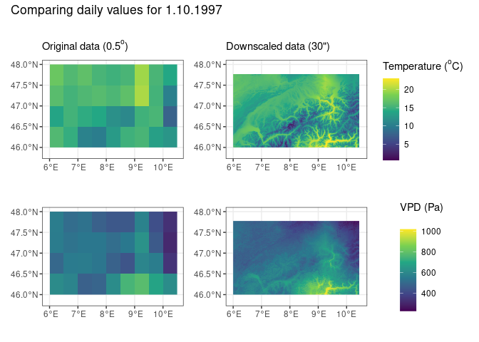

```r
source("R/plot_daily_comparison.R")

plot_daily_comparison(year = 1997,
                      month = 10,
                      day = 1)
```

The downscaled maps of both temperature and VPD values are in similar ranges to the 0.5$^{\text{o}}$ original data. The local variations reflect the topography of Switzerland, as we would have expected. Next, we will compare the downscaled temperature and VPD to measurements taken at surface level.

## Data evaluation

We are interested in daily averages of temperature and VPD from various Swiss FLUXNET sites (see information [here](https://fluxnet.org/sites/site-list-and-pages/). In the following plot, we show the locations of the flux sites in Switzerland. The plot is interactive and allows to hover over the dots to read their names.

```r
# Define FLUXNET site information from online table
fluxnet_sites <- data.frame(
  site_code = c("CH-Cha", "CH-Dav", "CH-Fru", "CH-Lae", "CH-Oe1", "CH-Oe2"),
  site_name = c("Chamau", "Davos", "Früebüel", "Laegern",
                "Oesingen grassland", "Oesingen crop"),
  lon = c(8.4104, 9.8559, 8.5378, 8.3644, 7.7319, 7.7337),
  lat = c(47.2102, 46.8153, 47.1158, 47.4783, 47.2858, 47.2864),
  elv = c(393, 1639, 982, 689, 450, 452),
  mat = c(9.5, 2.8, 7.2, 8.3, 9, 9.8),
  map = c(1136, 1062, 1651, 1100, 1100, 1155),
  igbp = c("Grassland", "Evergreen needleleaf forest", "Grassland",
           "Mixed forest", "Grassland", "Crop")
)

# Plot locations with leaflet
leaflet() |>
  addProviderTiles(providers$Esri.WorldImagery, group = "World Imagery") |>
  addCircleMarkers(lng = fluxnet_sites$lon,
             lat = fluxnet_sites$lat,
             label = paste0(fluxnet_sites$site_code, " (", fluxnet_sites$site_name, ")")) |>
  fitBounds(lng1 = 5.966667, lng2 = 10.45833,
            lat1 = 45.83333, lat2 = 47.775)
```

[interactive chart not shown]

These 6 sites represent different land cover classes, from grasslands (Chamau, Früebüel and Oensingen 1) and crop fields (Oensingen 2) to mixed (Laegern) and evergreen needleleaf forests (Davos). The Früebüel site is the wettest, with mean annual precipitation of 1650mm, mean annual temperature of 7 $^\text{o}$C and an elevation of 980m. Davos sits highest, at 1600m of elevation, it is cold (3 $^\text{o}$C mean annual temperature) and dryer (1060mm). The remaining 4 sites are at 400-700m of elevation, with mean annual temperatures of 8-10 $^\text{o}$C and precipitation of 1100-1150mm. With this data, we have a good representation of the Swiss Plateau but not so good of mountaineous areas, for which the downscaling is also more complicated due to its topology. For all sites there are at least 6 years of measurements, with the oldest having 18 years of data.

### Visualisation of time series

We saved the daily downscaled data in files grouped by month and year. Therefore, to get the daily time series of temperature for any given pixel, we need to open all files and extract values for just that pixel, then concatenate them all. Here we extract a time-series of downscaled temperature and VPD for the 30x30” pixels corresponding to the Swiss FLUXNET sites and save the data frame for later.

```r
# Load function
source("R/get_downscaled_time_series.R")

# Extract downscaled daily time series for a given set of sites and years
daily_downscaled <- get_downscaled_time_series(
  years = 1997:2014,
  fluxnet_sites = fluxnet_sites
)

# Save time series of downscaled data for Swiss sites
save(daily_downscaled, file = "data/daily_downscaled.rda")
```

Finally, we can visually compare the downscaled values to the measurements from FLUXNET2015. For simplicity, we will only plot the data from Davos but include all quality measures the table below.

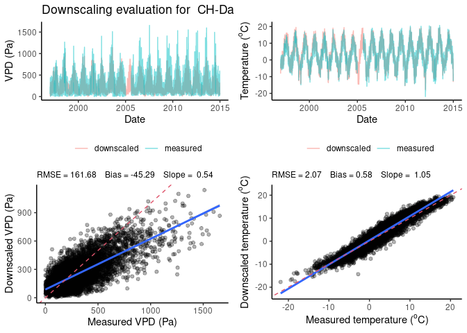

```r
# Load functions to compare and plot data
source("R/get_fluxnet_data.R")
source("R/plot_comparison_site.R")

plot_comparison_site(
  daily_downscaled,
  path_fluxnet,
  site_code = "CH-Dav"
)
```

The following table shows four summary metrics, for temperature and VPD, to evaluate the performance of the downscaling for each site separately. As usual, we report the root mean squared error (RMSE), the bias and the slope between downscaled and measured values. The fourth metric is a normalized version of the RMSE, where we divide by the standard deviation of the downscaled values, which gives an idea of the error proportional to the magnitude of each variable. This also allows to compare the performance on temperature and VPD directly.

```r
# Load function to create comparison table
source("R/compare_downscaled.R")

metrics <- compare_downscaled(
  daily_downscaled,
  path_fluxnet
)

knitr::kable(metrics,
             col.names = c("RMSE", "Bias", "Slope", "RMSE norm",
                           "RMSE", "Bias", "Slope", "RMSE norm"
                           ),
             digits = 2) |>
  kableExtra::add_header_above(c(" " = 1, "VPD" = 4, "Temperature" = 4)) |>
  kableExtra::kable_styling(full_width = TRUE)
```

|  | VPD RMSE | VPD Bias | VPD Slope | VPD RMSE norm | Temperature RMSE | Temperature Bias | Temperature Slope | Temperature RMSE norm |
| --- | --- | --- | --- | --- | --- | --- | --- | --- |
| CH-Cha | 158.79 | 56.74 | 0.83 | 0.57 | 2.01 | 0.92 | 0.96 | 0.27 |
| CH-Dav | 161.68 | -45.29 | 0.54 | 0.96 | 2.07 | 0.58 | 1.05 | 0.28 |
| CH-Fru | 195.08 | 65.40 | 0.62 | 0.87 | 1.58 | 0.17 | 0.92 | 0.23 |
| CH-Lae | 140.27 | -36.53 | 0.72 | 0.53 | 1.66 | 0.89 | 0.93 | 0.22 |
| CH-Oe1 | 167.78 | 20.25 | 0.84 | 0.52 | 1.72 | 0.69 | 0.94 | 0.24 |
| CH-Oe2 | 167.42 | 21.55 | 0.79 | 0.58 | 1.55 | 0.66 | 0.94 | 0.22 |

From the results above, we can conclude that the downscaling of temperature works quite well for all sites, with RMSE values between 1.5 and 2 $^{o}$C. On average, we predict a temperature that is less than 1 degree Celsius higher than the measured temperature, as indicated by the bias. There does not appear to be any strong systematic error because the slope is close to 1.

On the contrary, the VPD downscaling is quite faulty. As we observe in the figure, we tend to underestimate VPD in the Davos site, despite capturing seasonal variations in VPD (seen in the time series plots). There is a systematic scaling error of approximately 50%, shown by the slope of the scatterplot. For all 6 sites, small VPD values are generally overestimated and large VPD values, underestimated.

The error may stem from the calculation of VPD from specific humidity (WATCH-WFDEI) and water vapor pressure (WorldClim) and the approximation used in this section, or from the fact that the values provided are averaged over large and heterogeneous regions. For example, the performance in Chamau is better, which hints that there may be a topological or vegetation type component to our error.

> NOTE: In your full report, there should be additional sections containing the modelling and statistical analysis components of the project. This example project goes over the data processing steps only.

## Conclusion

Temperature downscaling exhibited promising results, showcasing the capability of our methodology to enhance spatial and temporal resolution. However, the same cannot be said for VPD downscaling, which yielded less favorable outcomes. This disparity may stem from the intricate nature of VPD, computed from multiple meteorological variables, making its accurate downscaling a more complicated task.

The consequences of poor downscaling on vegetation modelling analyses are far-reaching. Inaccuracies in downscaled VPD values can cascade into erroneous predictions of plant water stress, transpiration, and ecosystem responses. Many vegetation models are trained on locally measured data like the FLUXNET2015 dataset, but are then upscaled to global values using remote sensing products like WATCH-WFDEI and WorldClim. The bad quality of downscaled data compromises the reliability of vegetation models, hindering our ability to make informed decisions in ecological management, conservation efforts, and climate change impact assessments.

As we look towards improving our processing workflow, multiple approaches emerge. Enhanced data assimilation techniques beyond de-biasing, careful consideration of variable transformations like the equations for VPD, and incorporation of extra topological variables like elevation and aspect and additional meteorological predictors can be explored. For example, we may study the relationship between FLUXNET2015 observations and topological and meteorological variables, together with average cell values from our downscaled values, in order to create a more sophisticated regression-based downscaling model. Moreover, leveraging high-quality ground-based measurements through calibration and validation exercises can potentially mitigate discrepancies between downscaled values and actual observations, leading to more accurate results.

In conclusion, this geographical data science project has brought us closer to the intricacies of climate data downscaling. While temperature downscaling showcased potential success, the challenges encountered in VPD downscaling emphasize the need for refinement. By continuously improving our workflow and incorporating ground-based measurements, we can bridge the gap between observed reality and downscaled data, enabling more accurate and insightful vegetation modelling analyses.

# References

Abtew, Wossenu, and Assefa Melesse. 2013. “Evaporation and Evapotranspiration Estimation Methods.” In, edited by Wossenu Abtew and Assefa Melesse, 63–91. Dordrecht: Springer Netherlands. https://doi.org/10.1007/978-94-007-4737-1_6.

Bonan, Gordon B., ed. 2008. “Global Cycles.” In, 2nd ed., 28–38. Cambridge: Cambridge University Press. https://doi.org/10.1017/CBO9780511805530.004.

Fick, Stephen E., and Robert J. Hijmans. 2017. “WorldClim 2: New 1-Km Spatial Resolution Climate Surfaces for Global Land Areas.” *International Journal of Climatology* 37 (12): 4302–15. https://doi.org/10.1002/joc.5086.

Pastorello, Gilberto, Carlo Trotta, Eleonora Canfora, Housen Chu, Danielle Christianson, You-Wei Cheah, Cristina Poindexter, et al. 2020. “The FLUXNET2015 Dataset and the ONEFlux Processing Pipeline for Eddy Covariance Data.” *Scientific Data* 7 (1): 225. https://doi.org/10.1038/s41597-020-0534-3.

Peñuelas, Josep, Philippe Ciais, Josep G. Canadell, Ivan A. Janssens, Marcos Fernández-Martínez, Jofre Carnicer, Michael Obersteiner, Shilong Piao, Robert Vautard, and Jordi Sardans. 2017. “Shifting from a Fertilization-Dominated to a Warming-Dominated Period.” *Nature Ecology & Evolution* 1 (10): 1438–45. https://doi.org/10.1038/s41559-017-0274-8.

Wang, Songhan, Yongguang Zhang, Weimin Ju, Jing M. Chen, Philippe Ciais, Alessandro Cescatti, Jordi Sardans, et al. 2020. “Recent Global Decline of CO <sub>2</sub> Fertilization Effects on Vegetation Photosynthesis.” *Science* 370 (6522): 1295–1300. https://doi.org/10.1126/science.abb7772.

Weedon, Graham P., Gianpaolo Balsamo, Nicolas Bellouin, Sandra Gomes, Martin J. Best, and Pedro Viterbo. 2014. “The WFDEI Meteorological Forcing Data Set: WATCH Forcing Data Methodology Applied to ERA-Interim Reanalysis Data.” *Water Resources Research* 50 (9): 7505–14. https://doi.org/10.1002/2014wr015638.

Yuan, Wenping, Yi Zheng, Shilong Piao, Philippe Ciais, Danica Lombardozzi, Yingping Wang, Youngryel Ryu, et al. 2019. “Increased Atmospheric Vapor Pressure Deficit Reduces Global Vegetation Growth.” *Science Advances* 5 (8): eaax1396. https://doi.org/10.1126/sciadv.aax1396.